# 第7回課題

# 課題1

Python言語で以下の要件を満たすプログラムを作成せよ

- 処理に関する要件
  - PCカメラで撮影した動画（画像を一定間隔ごとに撮影し640x480にリサイズしたもの）から，以下に示す2つのマスク画像(laplacian_maskとfgmask_mask)を作成せよ
    - laplacian計算した画像の色は，黒（負の値），もしくは白（正の値）を持っている．白に近い画素（laplacian[y,x]>10）を赤色に変換するmask画像(ここではlaplacian_maskと呼ぶ)を作成せよ
    - 背景差分計算した画像を幅16px x 縦16pxの正方形領域に画像を分け，それぞれの領域で白色の画素数の和を計算せよ(各正方形領域から計算した白色の画素数の和は，30行40列の2次元配列の形になる)
    - 背景差分計算した画像の各画素の色の平均値(すなわち背景差分画像で白色画素が占める割合)を計算し，白色画素が占める割合より白色画素が多い正方形領域を表示し，それ以外の領域は見せないようにするmask画像（ここではfgmask_maskと呼ぶ）を作成せよ
      - ヒント：表示したい領域ではmask画像の白(255,255,255)，表示したくない領域ではmask画像の黒(0,0,0)となるようにmask画像を作成する
  - PCカメラで撮影した動画（画像を一定間隔ごとに撮影し640x480にリサイズしたもの）から得た画像の画素を，2つのmask画像を使って以下のように変換せよ
    - fgmask_mask画像が白，かつ，laplacian_maskが赤の場合は元の画素色を維持せよ
    - fgmask_mask画像が白，かつ，laplacian_maskが黒の場合は元の画素色を維持せよ
    - fgmask_mask画像が黒，かつ，laplacian_maskが赤の場合は赤色に変更せよ
    - fgmask_mask画像が黒，かつ，laplacian_maskが黒の場合は黒色に変更せよ
  - maskで変換した画像をPC画面に表示し，その様子をスクリーンショットで保存せよ
    - あるウィンドウのスクリーンショットのとり方は`command + shift + 5`のショーットカットキーを押すとよい
- 実装に関する要件
  - 一連の処理が`lecture07_01.py`を実行することで確認できること（要するにこのファイル名で実装すること）
  - (加点要素)「オリジナル画像を受け取り，マスク作成・画像加工をして加工済みの画像を返す」処理を`my_module/学籍番号/lecture07_01_module.py`の中に実装すること．（注：関数として実装してもクラスとして実装してもよい）

| ファイル名 |
| --- |
| lecture07_01.py（全員提出） |
| lecture07_01_module.py（加点狙いの人はこのファイルも提出） |
| lecture07_01_k21999.png（全員提出） |

# スクリーンショットの例

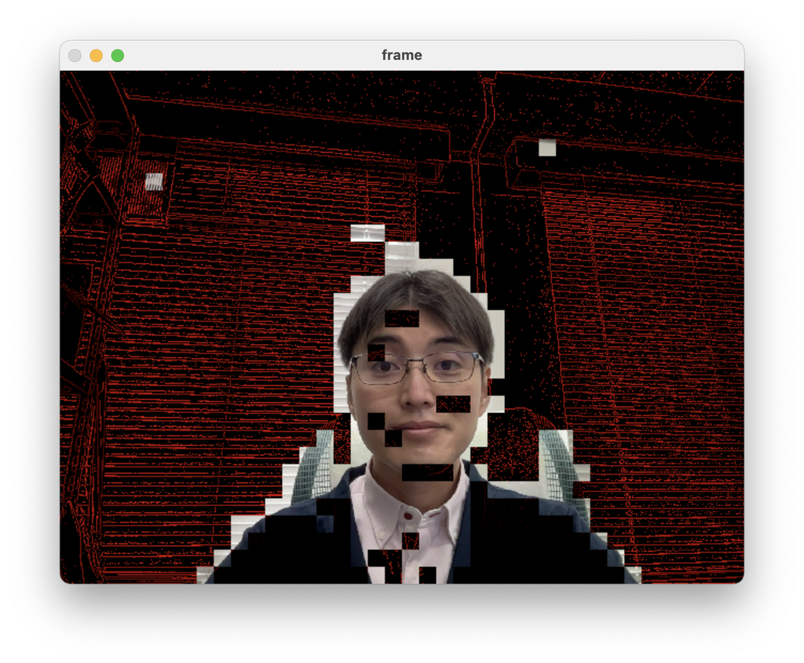

Zoomなどの背景に相当する箇所はエッジだけを表示し，人物が映っている領域はそのまま表示するイメージ

# ヒント

1. 資料の`lecture07_01_example.py`を参照のこと
2. モジュール化（加点要素）は画像処理部分の実装が終わってからでも可能なので，先に処理の要件を満たすプログラムを作成し，後からファイルを分けると良い

# 提出について

moodleにて提出先を作成します。

作成したソースコード1つ（加点狙いの人は2つ）とスクリーンキャプチャした画像１つ(png)を提出してください。

提出期限等は、moodleを参照してください．